# Assignment 3

#### Apply some generic functions to a `lm` function

print, summary, plot

#### Questions – Playing with the lm function

Consider the `faithful` dataset – can one predict the waiting time to the next eruption (variable `waiting`) from the eruption time (variable `eruptions`)?

#### Question 1

Construct a scatterplot of eruptions (horizontal) against waiting (vertical).

```r
library(tidyverse)

eruption = faithful$eruptions
waiting = faithful$waiting
head(cbind(eruption, waiting))
```

```
##      eruption waiting
## [1,]    3.600      79
## [2,]    1.800      54
## [3,]    3.333      74
## [4,]    2.283      62
## [5,]    4.533      85
## [6,]    2.883      55
```

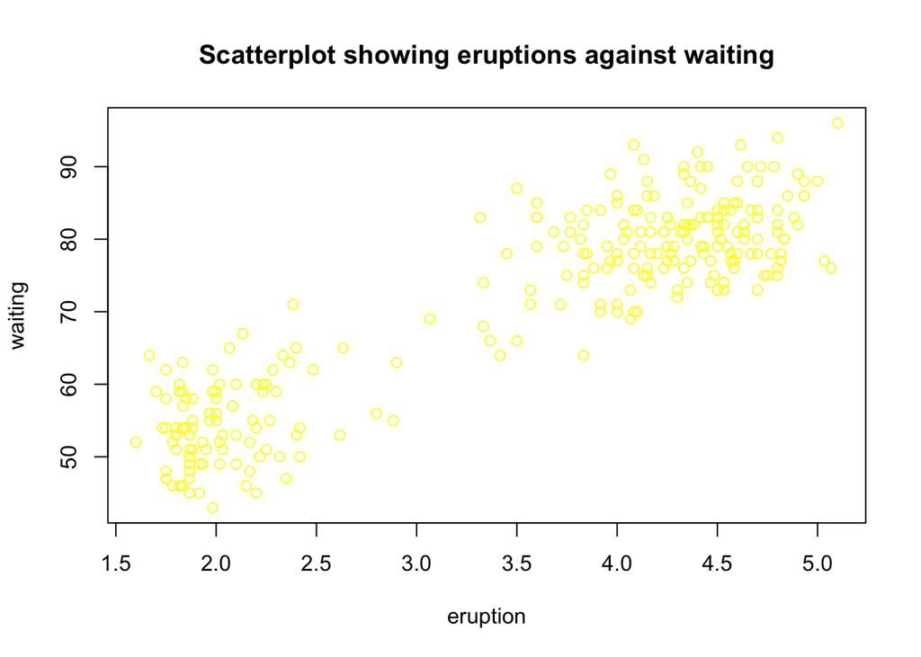

```r
plot(eruption, waiting, col="yellow", main="Scatterplot showing eruptions against waiting")
```

#### Question 2

Using the lm function find the equation of the best line for predicting waiting time from the eruption time. Add the best line of fit to your scatterplot.

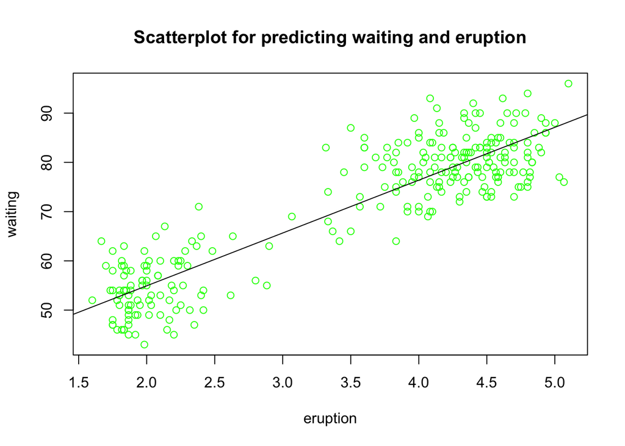

```r
plot(eruption, waiting, col="green", main="Scatterplot for predicting waiting and eruption")
abline(lm(waiting ~ eruption))
```

#### Question 3

Rerun the lm() function, storing the output to the variable fit.

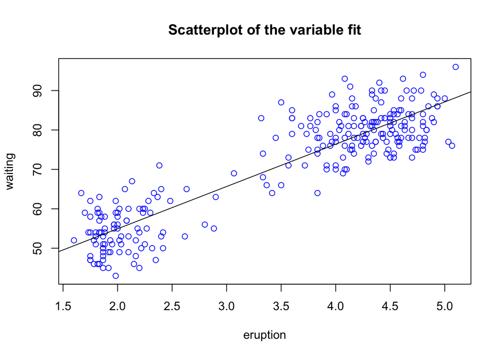

```r
plot(eruption, waiting, col="blue", main = "Scatterplot of the variable fit")
fit <- abline(lm(waiting ~ eruption))
```

#### Question 4

Display the first five predicted values and the first five residual values.

```r
fit <- lm(waiting ~ eruption)

head(fit$fitted.values)
```

```
##        1        2        3        4        5        6
## 72.10111 52.78775 69.23629 57.97017 82.11186 64.40795
```

```r
head(fit$residuals)
```

```
##         1         2         3         4         5         6
##  6.898894  1.212248  4.763708  4.029832  2.888139 -9.407953
```

#### Question 5

Use the summary function on the variable fit to get some new regression output. Explain what additional information is displayed.

```r
fit <- lm(waiting ~ eruption)
summary(fit)
```

```
##
## Call:
## lm(formula = waiting ~ eruption)
##
## Residuals:
##      Min       1Q   Median       3Q      Max
## -12.0796  -4.4831   0.2122   3.9246  15.9719
##
## Coefficients:
##             Estimate Std. Error t value Pr(>|t|)
## (Intercept)  33.4744     1.1549   28.98   <2e-16 ***
## eruption     10.7296     0.3148   34.09   <2e-16 ***
## ---
## Signif. codes:  0 '***' 0.001 '**' 0.01 '*' 0.05 '.' 0.1 ' ' 1
##
## Residual standard error: 5.914 on 270 degrees of freedom
## Multiple R-squared:  0.8115, Adjusted R-squared:  0.8108
## F-statistic:  1162 on 1 and 270 DF,  p-value: < 2.2e-16
```